# What all Factors affect the result(winning) of a match

Predict the winner of IPL 2019

Sourabh Gupta  
A cricket Fan

March 22, 2019

# Agenda

- Teams Playing 2019 and Winning Stats
- Top Batsmans Since 2008
- Top Bollers SInce 2008
- How Batting affect the winning Probability
- How First 5 and Last 5 overs score affect the win
- How Bowling affect the winning Probability

# Teams Playing 2019 and Winning Stats

- There are 8 teams playing the IPL this year
  - Mumbai Indians held the trophy for 3 times (2013, 2015, 2017)
  - Chennai Super Kings and Kolkata knight rides held trophy twice
- Mumbai Indians hosted most number of matches
  - Mumbai home ground of Mumbai Indians has hosted 85 matches since 2008
  - Mumbai Indians has won maximum number of matches till now

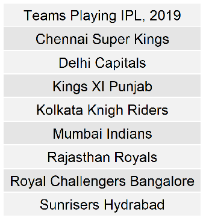

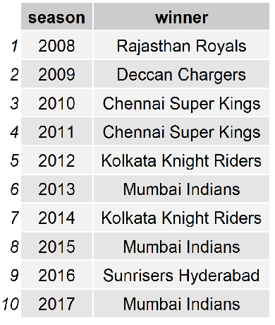

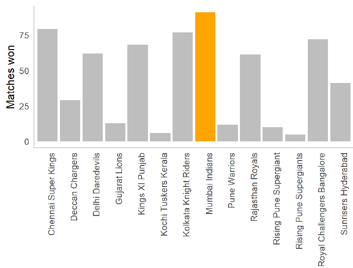

# Top Batsmans Since 2008

- Scoring run is batsman Job:
  - Suresh Raina, Virat Kohli **Rohit Sharma**, Gautam Gambhir, David Warner
  - All 4 players have great Strike rate except Gautam Gambhir - He is not a finisher
  - **Rohit Sharma** plays for **Mumbai Indians** is the best among 4, because IPL is the game of hitting hard
  - Virat Kohli will be the player to watch this season because he is being compared to Sachin Tendulkar these days

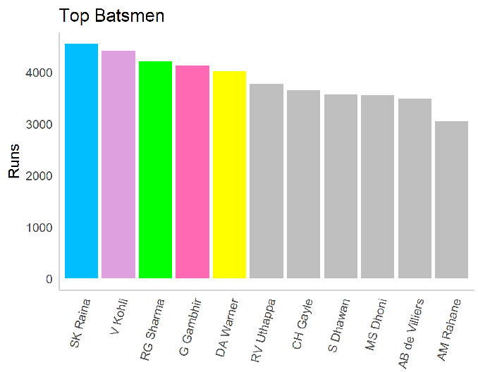

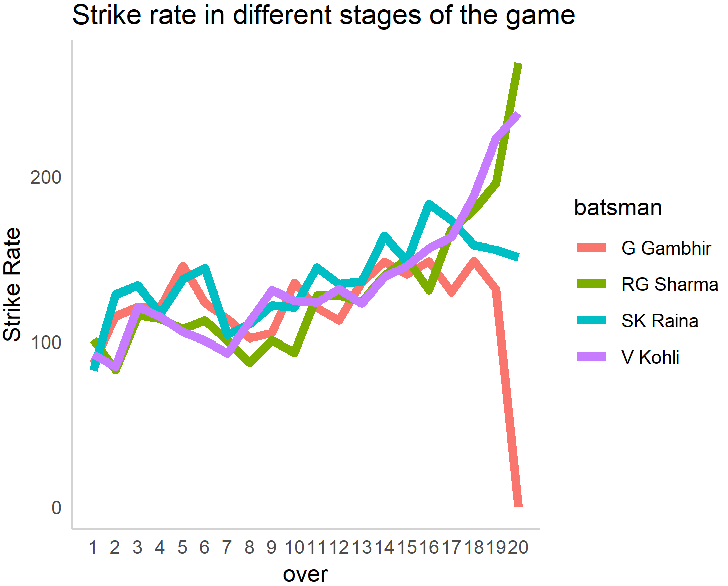

# Top Bowler Since 2008

- Taking wickets is job of bowler
  - Taking wickets increases the chances of winning for any team
  - **SL Malinga, Harbajan Singh** also play for **Mumbai Indians** are two best bowlers among Top 4
  - Amit Mishra will be the bowler to watch this season, he is young talent in cricket

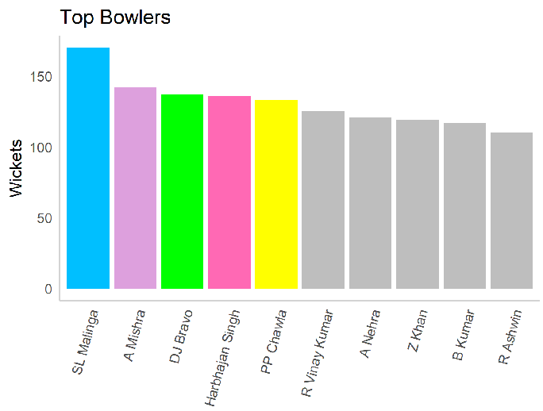

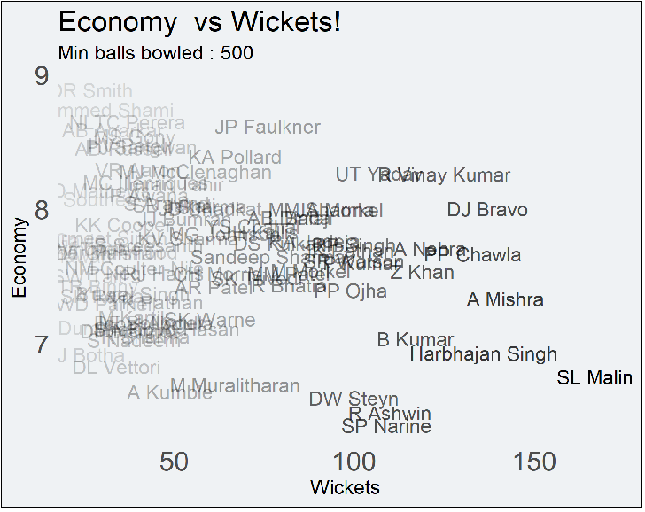

# How Batting affect the winning Probability

- Staying on the wicket and keep scoring runs is very crucial for any team
  - If individual score of any player in the team crosses 50; the probability of winning the match becomes more than 65%
  - If there is a successful partnership between 2 players exceeds 60 runs; the probability of winning the match becomes approx 90%

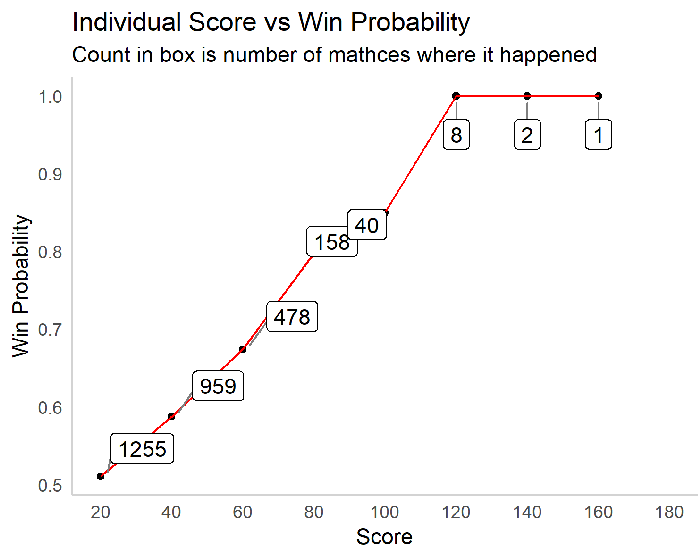

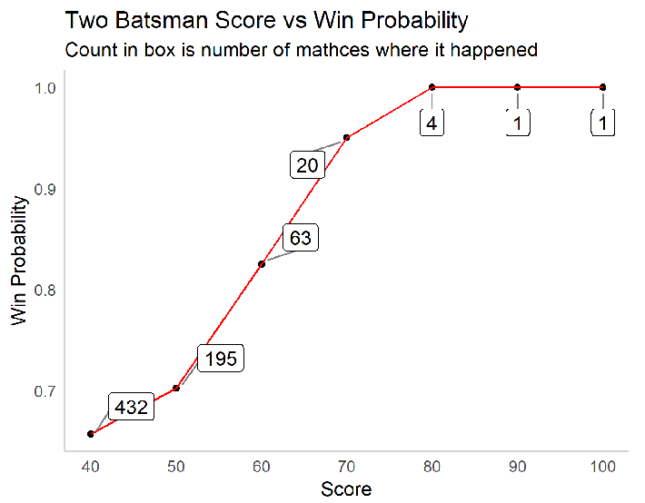

# How First 5 and Last 5 overs score affect the win

- Making good score in early stage of the match increases chances of winning
  - First 5 overs are very useful for any batting team and team scores more than 50 runs, which is not easy, probability of winning becomes more than 80%
  - Last 5 overs; every team tries to score as much they can and some times they loose wickets as well due to this
  - If any team scores more than 60 score in last 5 overs probability of winning becomes more than 65%

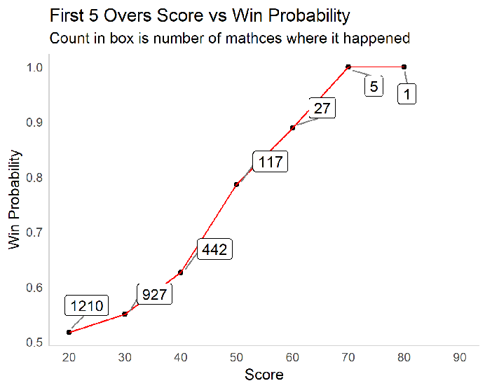

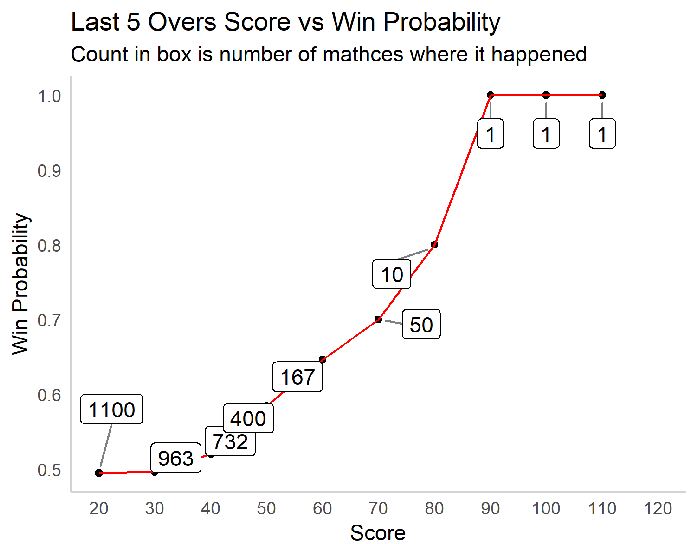

# How Bowling affect the winning Probability

- Taking wickets is very important for any bowling team
  - In the early stage of match, if bowling team gets success in taking only 1 wicket, probability of winning becomes 60%
  - If Bowling team gets more than 2 wickets in first 5 overs of match, they have even high probability of winning

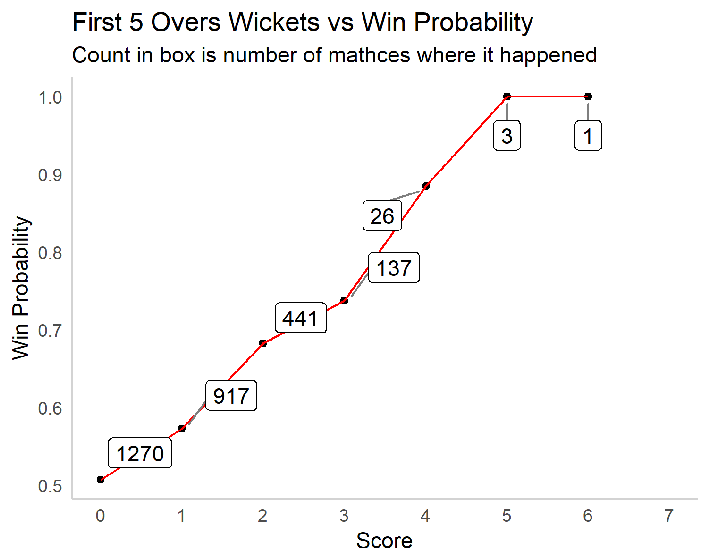

- Prediction, Mumbai Indians has won 3 trophies out of 10. Also we can see, Mumbai Indians have both Top batsman and Top bowlers in its squad. Sachin Tendulkar, the biggerst player of cricket history is their coach and mentor. We are expecting Mumbai Indians will lift the trophy this time as well.
- PS: What ever analysis be made, the success rate of Prediction is very minimal. So Keep Calm and watch the match. Anything could be a turning point in the match.

# Contact me for more information

- Email - **guptasourabh@seattleu.edu**
- Phone - **(425)-633-6988**